# PARİTE: SIĞIR — THE CATTLE PARITY

### Why is meat so expensive? The answer from 55 years, three continents, and 993 months

**Namık Akman · namikakman.dev** · Data cutoff: June/July 2026 · Sources: FRED/BLS · EC Agrifood · TÜİK/EVDS

Anyone who has stood in front of a butcher's display case and read the price tag twice is asking the same question: where does this price come from? While searching for the answer, I stopped looking at the price itself. Because the price of meat, on its own, tells you nothing; a steer eats feed for months before it reaches slaughter, and that feed has a price too. The real story lies in the ratio between the two: **when you sell one unit of meat, how many units of feed can you buy?** I call this the parity.

This report tells you everything that can be read from this single ratio, drawing on a combined 993 months of data from three continents. The tag in the display case is not an arbitrary number; it is the delayed invoice of decisions made in the barn years ago, of cows sent to slaughter, and of biology's unhurried calendar. **The answer to why meat is expensive is not hidden in today — it is hidden three years in the past.**

> **So what do we mean by "feed"? Not stuffed eggplant.** A beef steer's plate has four line items: energy (corn, barley), protein (soybean and sunflower meal), roughage (silage, straw), and premix (vitamins and minerals). "Feed" in this report is measured slightly differently in each series:
> - **US:** the pure **corn PPI** — the energy backbone of the American feedlot ration, and the only unbroken monthly series reaching back to 1971.
> - **EU:** the price of **feed corn** (€/tonne). We initially assumed compound feed; a robustness check confirmed it was corn one-for-one, and we corrected the label — this report records its own mistakes.
> - **Türkiye:** TÜİK's **"prepared animal feeds"** PPI item — compound feeds at the factory gate.

> An honest footnote: on-farm roughage such as silage and straw sits outside these indices; our ratio measures the "purchased feed" spread — which is exactly what squeezes a feeder's cash flow.

> **Is this apples to apples?** In level terms, no — and this report never races levels against each other in the first place; every cross-country comparison is made with a 2015=100 index or with correlations. The US and EU denominators are raw corn, the Turkish denominator a factory feed index — a slice of the TR series' relatively calm volatility comes from this measurement asymmetry, while the US-EU comparison turns out to be even more apples-to-apples than expected.

```
ABD: 666 ay (1971-01→2026-06) · AB: 129 ay · TR: 198 ay · toplam 993
```

## 1 · The story in brief

The first thing the data says is this: **we are standing in a very strange corner of history.** In America, the cattle-to-feed parity today is 2.44 — higher than 99.7 percent of the 666 months measured since 1971, and just below the all-time record of 2.54 (August 2025). Europe broke its own record at 3.51 in February 2026, and Türkiye saw its peak of 1.40 in April 2024. Three geographies are living the same story — the correlation of annual changes between the US and the EU is 0.88. In the US, four troughs across four different decades have traced the same trajectory: a three-to-fourfold rise within 40-52 months of the bottom. And in all three series, **the peak appears to be behind us:** this report is not a fire alarm; it is a photograph of a moment just past the blaze's crest, in an era when the ash has always taken two to four years to cool.

```
──────────────────────────────────────────────────────────────────
ABD · bugün 2.44× (2026-06) · yüzdelik %99.8 · zirve 2.54 (2025-08) · dip 0.40 (1974-12)
AB  · bugün 2.82× (2026-07) · yüzdelik %88.3 · zirve 3.51 (2026-02) · dip 1.42 (2022-06)
TR  · bugün 1.31× (2026-06) · yüzdelik %92.9 · zirve 1.40 (2024-04) · dip 0.70 (2021-12)
──────────────────────────────────────────────────────────────────
ABD onyıl ortalamaları: 1970'ler 0.80 → 1980'ler 1.00 → 1990'ler 1.07 → 2000'ler 1.22 → 2010'ler 1.10 → 2020'ler 1.34
Yıllık değişim korelasyonları: ABD–AB 0.88 · AB–TR 0.68 · ABD–TR 0.58
──────────────────────────────────────────────────────────────────
MESAJ: Yem belirler — yem pahalanınca sürü küçülür; sürü küçülünce et, her kıtada pahalanır.
```

## 2 · The US: a feeder's 55 years

Picture a Texas feedlot operator who started out in 1974. In his first year, the parity collapses to 0.40 — the Soviets have snapped up American grain, the oil crisis has inflated costs. In 1987, the first great peak at 1.75. In 1996, 0.44. In 2008, the food-and-fuel crisis: 0.54. In 2011, 0.55. After the Great Plains drought, 1.87 in 2014. And in 2021, the final plunge to 0.58; the corn PPI had risen 153 percent in two years.

Today his screen reads 2.44 — in only two of 666 months has he ever seen higher. The 55-year average is 1.08; decade averages have climbed from 0.80 to 1.34. **Over a lifetime he has seen both ends of the pendulum's swing; he has never stood this high.**

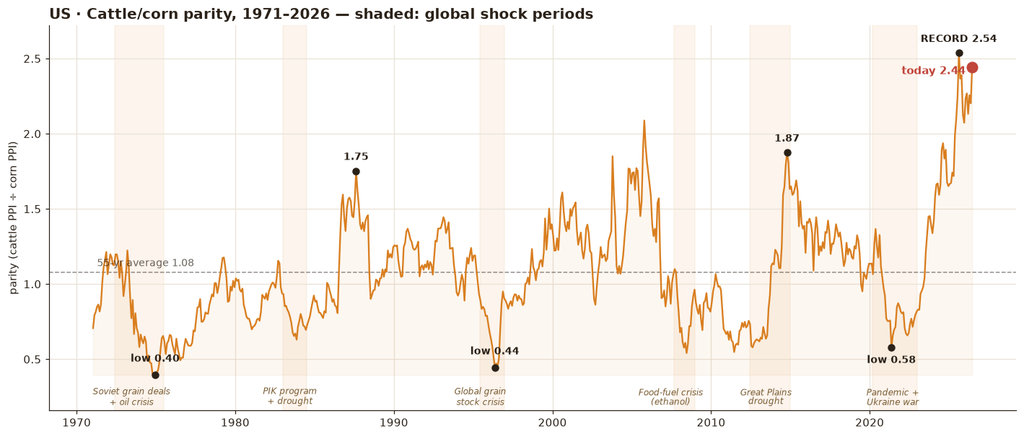

*Below, the regime view of the same series: the five-year band is both drifting upward and widening — uncertainty is growing along with the level.*

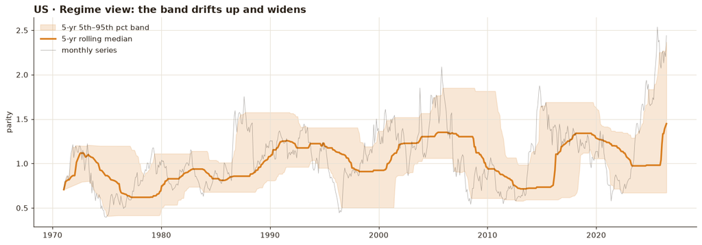

```
Kayan medyan: 1980'de 0.75 → 2000'de 0.92 → bugün 1.45
```

## 3 · The cycle lab: four troughs, one movie

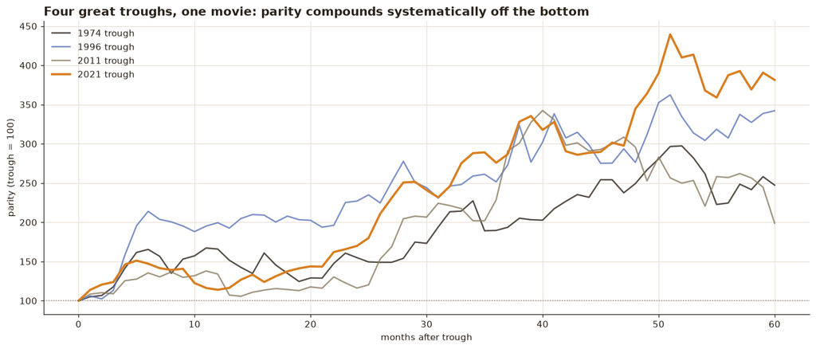

```
1974 dibi: 60 ayda ×3.0 (zirveye 52 ayda)
1996 dibi: 60 ayda ×3.6 (zirveye 51 ayda)
2011 dibi: 60 ayda ×3.4 (zirveye 40 ayda)
2021 dibi: 60 ayda ×4.4 (zirveye 51 ayda)
```

When we stack the four troughs on top of each other (1974, 1996, 2011, 2021; trough=100, next 60 months), what emerges is unsettlingly regular: the 1974 trough tripled by month 52, the 1996 trough reached 3.6 times by month 51, the 2011 trough 3.4 times by month 40, the 2021 trough 4.4 times by month 51.

**History does not repeat, but it rhymes; and the rhyme is written not by the central bank but by the cow herself.** When feed gets expensive, producers lose money and send breeding stock to slaughter; the herd shrinks. But a slaughtered cow is not replaced by decree: it takes roughly three years for a heifer's calf to reach slaughter weight. That biological lag explains why the road from trough to peak is always 40-52 months long. The interest-rate cycle can be hurried; a gestation period does not negotiate.

## 4 · 55 years in a single frame

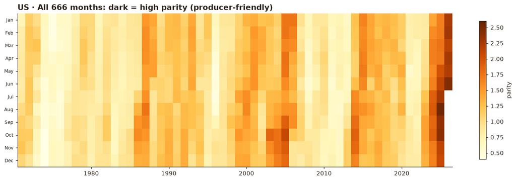

```
Sağ üstteki koyu blok = 2023–26 rekor bölgesi. Dikey açık şeritler = 1974, 1996, 2021 yem şokları.
Yatay desen: Eyl–Eki satırları sistematik koyu → hasat mevsimselliği.
```

## 5 · Europe's cushion, Türkiye's invoice

Europe lives the same story in a padded room: an average of 2.24; a trough of 1.42 in June 2022, a record of 3.51 in February 2026. Since the denominator is the same grain on both continents, the softness must come from the numerator: CAP subsidies and contract production make carcass prices far less volatile than the American cattle PPI — **the suspension is not in the feed, it is in the meat.** (Part of it is also a period effect: the EU series starts in 2015 and never saw extremes of the 1974 or 1996 type.)

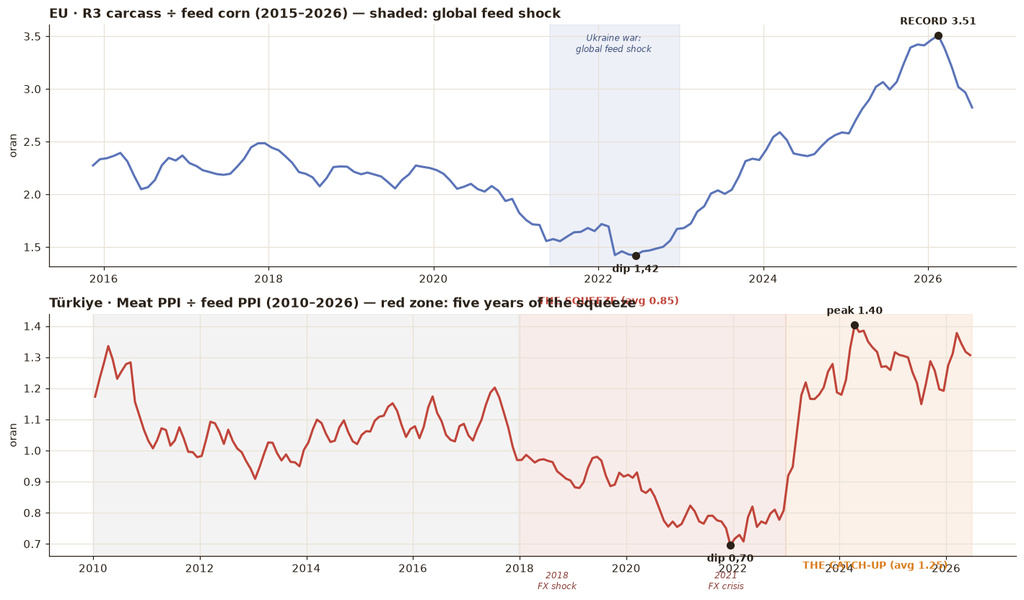

## 6 · Three continents, one pulse

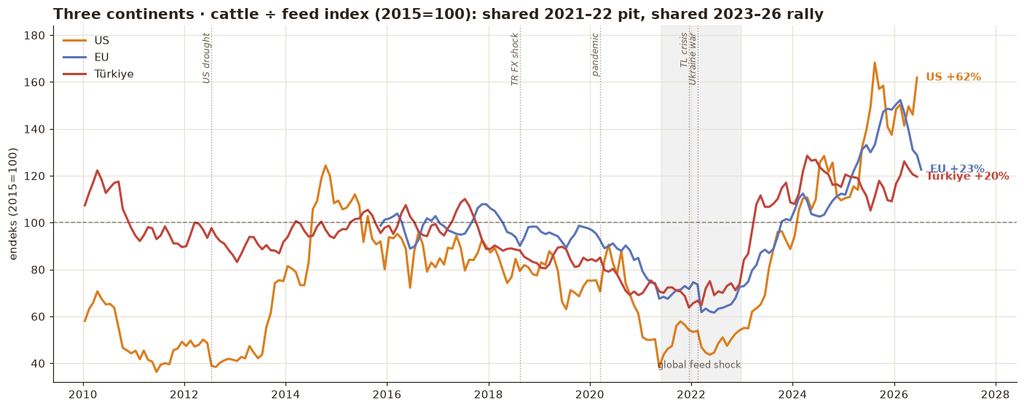

*The scatter below pairs the US's and EU's annual changes year by year — the closeness of the points to the line is the 0.88 correlation itself.*

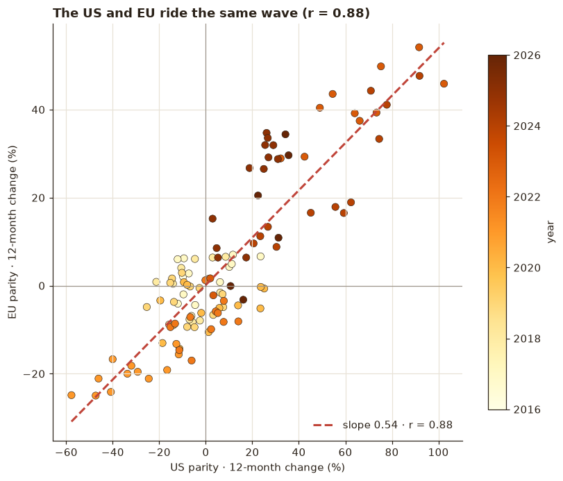

```
ABD–TR korelasyonu 0.58, AB–TR 0.68: Türkiye küresel dalga + kur bileşkesi.
```

## 7 · Do the shocks share a calendar?

The US and the EU move in perfect sync — the highest correlation (0.88) comes at zero months' lag. **Türkiye's clock may run slightly fast against Europe — but not against the US.** Testing every shift from −12 to +12 months, TR's strongest match with the US does fall at a four-month lead, but the correlation there is 0.607 against 0.579 at zero lag. A gain of 0.028 is the same reading twice, not a lead, and we withdraw the claim. Against the EU the case is better though still weak — 0.747 at a three-month lead against 0.670 at zero, a gain of 0.076 — and we report it only because there is a mechanism for it: feed built on imported inputs writes currency moves into its price almost immediately. The sequence of troughs: US May 2021 → Türkiye December 2021 → EU June 2022. The peaks: Türkiye April 2024 → US August 2025 → EU February 2026. **The crisis begins in the Atlantic, hardens in Ankara through the exchange rate, and reaches Brussels last — and in its gentlest form.** That ordering of turning points is the evidence for the sequence; the lag correlations are too weak to add anything to it.

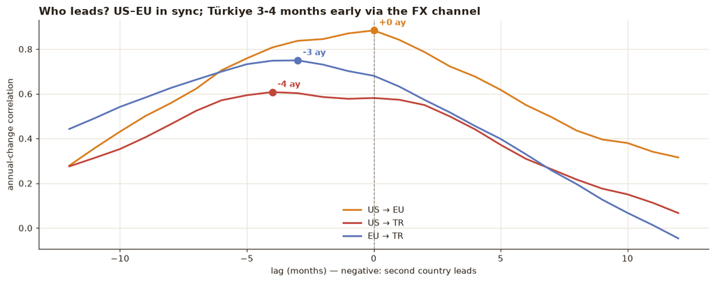

```
Troughs: US 2021-05 → TR 2021-12 → EU 2022-06  |  Peaks: TR 2024-04 → US 2025-08 → EU 2026-02
```

## 8 · So where should a feeder be? A report card

America is where the pendulum swings hardest: annual-change volatility of 31%, a -58% year on record, and the longest stretch below average lasting 71 months — nearly six years of living "below normal". In exchange, the ceiling is the highest: the market standing at the 99.7th percentile today, the one that returned 4.4x in 60 months off the trough, is the same market. Europe is "earn less, sleep well": the worst annual drop is -25%, the longest below-average stretch 45 months. Türkiye's affliction is not volatility but duration: its ratio volatility is the lowest of the three (16%), yet its below-average stretch ran 64 months — with the currency and financing layer stacked on top, neither of which this ratio captures.

The verdict — as far as the data goes, and honestly: **the question of "when" comes before "where";** in all three markets, what wins is not geography but knowing where you stand in the cycle. As a character test: if you can stomach the pendulum, the US; if you seek stability, the EU; if you can read the two-layered game — global cycle plus currency — Türkiye. One more note: land, labor, subsidy payments, and financing costs sit outside this dataset; a real business decision takes this report card **plus** those line items.

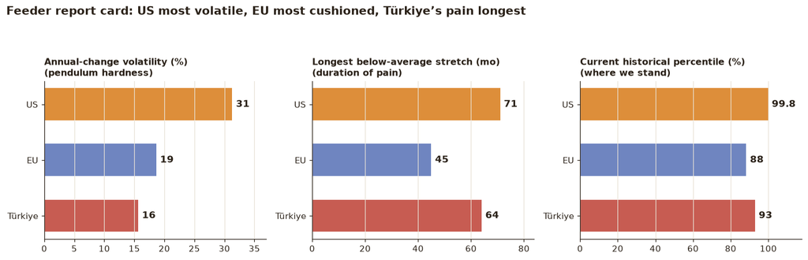

```
Worst year: US -58% · EU -25% · TR -20%  |  Trough→peak amplitude: US ×4.4 · EU ×2.5
```

## 9 · The producer's P&L: anatomy of a 100-lira sale

So far we have talked in ratios; now let us turn the ratio into a feeder's **profit-and-loss statement.** Our data covers only meat and feed prices; we have no series for calf purchases, labor, or financing. So we build an honest **stylized model** — assumptions on the table:

> **The model (per 100 units of sales revenue):** the calf at **45** and other costs (labor, energy, veterinary, upkeep) at **15** are held fixed — typical ranges from the sector literature. **The feed line is alive:** calibrated to equal 35 at each region's long-run average parity, varying inversely with the parity (double the parity, halve the feed burden). Financing costs are not in the model — in the Turkish reality, they are an extra item that squeezes the table further.

This simple machine tells each region's story at a glance. **At the American feeder's 1974 trough,** the feed line alone leaps to 94: a 100-lira sale costs 155 — every sale pulls 55 out of his pocket. There is your explanation for the savagery of American herd liquidations. **The Turkish feeder's 2021 trough** looks "milder": a loss of 12 per 100. But the real devastation lies not in the ratio but in the duration — that loss band lasted five years, and adding the financing costs the model omits darkens the picture further. **Today, all three regions are in the green:** the US writes ~25, the EU and Türkiye ~12 each per 100 of revenue — among the sweetest windows visible with calf and other costs held fixed.

One more honesty note: in reality the calf price is cyclical too — calves get cheap at the trough (softening the loss) and expensive at the peak (trimming the profit). The fixed-45 assumption makes the extremes look a little sharper than they were; it affects the dose, not the direction.

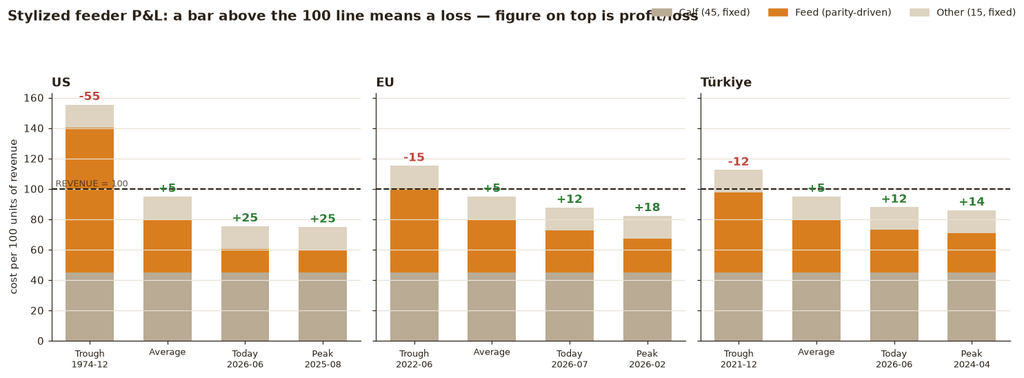

```
US: dip kârı -55 · bugün +25 · zirve +25  (100 gelir başına)
EU: dip kârı -15 · bugün +12 · zirve +18  (100 gelir başına)
Türkiye: dip kârı -12 · bugün +12 · zirve +14  (100 gelir başına)
```

## 10 · Robustness test: what if the denominator were corn everywhere?

We took the "not apples to apples" objection seriously and built the test: a second dataset fixing the denominator to corn in every region (`data/corn-parity.json`). The result in three sentences:

**In the US and the EU, the picture does not change — because it already was corn.** The US denominator was corn PPI by definition. In the EU, the test uncovered something we did not expect: the series we had been using under the "compound feed" label turned out to be the EC portal's **feed corn** series itself — all 129 months matched one for one. So the US-EU comparison was even more apples-to-apples than we feared: both continents divide by the same grain. (We corrected the EU labels throughout the report; it was this test that found the error — which is exactly what robustness tests exist for.)

**In Türkiye, the test cannot be run — and that is itself a finding.** We scanned the entire catalog of the central bank's EVDS system: 611 data groups, thousands of series. There is no monthly corn *price* series; everything under the name "Mısır" turned out to be Egypt the country — tourism revenue, the Egyptian pound, IMF macro series ("mısır" is Turkish for both corn and Egypt). The best official monthly tool available to an analyst tracking Turkish feed inflation is the "prepared animal feeds" PPI we already use. The measurement-asymmetry caveat therefore lives on a single border: between the US/EU and Türkiye. We have calibrated our interpretations accordingly.

## 11 · Conclusion: reading the late phase

The data's message today is clear: **we are in the late phase of the cycle.** The peaks are behind us in all three geographies — the US saw 2.54 in August 2025, the EU 3.51 in February 2026, Türkiye 1.40 in April 2024 — and in past cycles the return from peak to average took two to four years. High profits are rebuilding the herd with every heifer withheld from slaughter; the mechanism's normalization arm is already at work.

**To the producer:** today's 2.44s and 1.31s are history's exception, not a permanent income assumption — build your borrowing around the 1.08 average, not the peak. **To the consumer:** the price in the display case is the invoice for slaughter decisions made three years ago; relief will come, but the calendar is written by the cow's biology, and patience is measured in years, not months. **To the policymaker:** the most expensive moment to intervene is the trough — had the producers crushed at 0.85 for five years in 2018-22 been protected, the 1.40 peak of 2024 would not have been this sharp.

Because the price of meat is nobody's choice; it is a cost story that begins in the barn, passes through the field, and reaches the display case three years late. **The only way to make the story cheaper is to read it from the beginning.**

*Data, code and film: namikakman.dev · [GitHub](https://github.com/namikakmandev/namikakmandev.github.io) — FRED/BLS · EC Agrifood · TÜİK/EVDS. PDF report (Turkish): `notes/parite-sigir-veri-raporu.pdf`. Interactive story: namikakmandev.github.io/parite-sigir.html*